# DIS Method Exploration

Shaun Roberts

4 October 2018

# My functions:

### Sample Uniques and Pairs: `sup`

`sup` is a function designed to calculate the number of sample uniques and observations in pairs in a data-set. Based of the `row.match` function in the `prodlim` R package.

```r
sup <- function(df){
  if(class(df) == "matrix"){ #Checks if df is a matrix, if so, changes it into a data frame
    df <- as.data.frame(df)
  }
  if(class(df) != "data.frame"){ #If df is not a dataframe, stops code.
    stop("df is not a data frame")
  }
  cdf <- do.call("paste", c(df[, , drop = FALSE], sep = "\r")) #Pastes together the elements in each row of df, creating a vector of character strings
  cmat <- do.call("paste", c(unique(df)[, , drop = FALSE], sep = "\r")) #Pastes together the elements in each row of the unique rows, creating a vector of character strings
  rm(df) #Removes df from the local environment to save memory?
  ma = match(cdf, cmat, nomatch = NA) #finds matches between cdf and cmat.
  c(sum(table(ma) == 1), 2*sum(table(ma) == 2)) #Makes R output the number of times sample uniques and number of records in pairs.
}
```

### Data Intrusion Simulation risk calculation: `disRisk`

`disRisk` calculates the probability of a correct match given that it is a unique match, $P(cm|um)$. This is the disclosure risk measure laid out by Skinner and Elliot. Require the sample frequency, the number of sample uniques, and the number of pairs.
$$P(cm|um) = \frac{Uf}{Uf + P(1-f)}$$
Where: $U$ is the number of sample uniques $f$ is the sampling fraction $P$ is the number of pairs

```r
disRisk <- function(samp.frac, p.vec){
  n.uni <- p.vec[1]
  n.pair <- p.vec[2]
  (n.uni * samp.frac) / (n.uni * samp.frac + n.pair * (1 - samp.frac))
}
```

### Explore DIS method: `more.vars.test`

`more.vars.test` is a way that I can explore the DIS method to see what happens if we add more variables, more levels to the variables, increase the size of the data-set, etc.

```r
more.vars.test <- function(reps, nrows, disclosure.risk, nlevels){
  output <- matrix(nrow = reps, ncol = 3)
  x = round(runif(nrows, 0, nlevels), 0)
  for(i in 1:reps){
    super <- sup(as.data.frame(x))
    output[i,] <- c(super, disRisk(disclosure.risk, super))
    x = cbind(x, round(runif(nrows, 0, nlevels[i]), 0))
  }
  output
}
```

# DIS Exploration:

### Initial Dataset:

We have assumed that the intruder will have access to some key/identifier variables. These are Age, Gender, Marital Status, Ethnicity, Occupation, Region, and Religion. We have also assumed that these key variables will have a number of levels. What these specific levels are does not influence how the DIS disclosure risk is calculated so we do not need to define them.

|  | levels |
| --- | --- |
| Age | 70 |
| Gender | 2 |
| Maritial Status | 4 |
| Ethnicity | 5 |
| Occupation | 9 |
| Region | 20 |
| Religion | 6 |

I created multiple synthetic data-sets which has these 7 variables and calculated the disclosure risk for them. Starting with a random uniformly selected variable calculating the disclosure risk, then adding in another variable and repeating until all 7 variables are in the data set. I assumed that the observations were from a SRS with a sampling fraction of 1/100.

### Dataset Size:

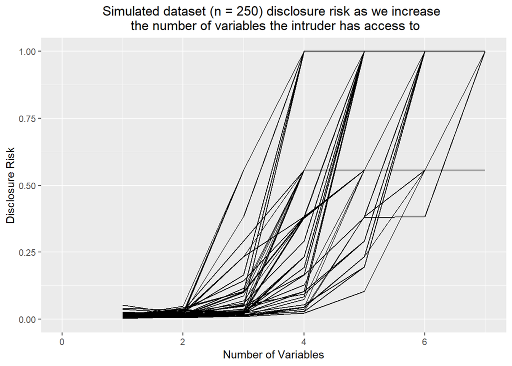

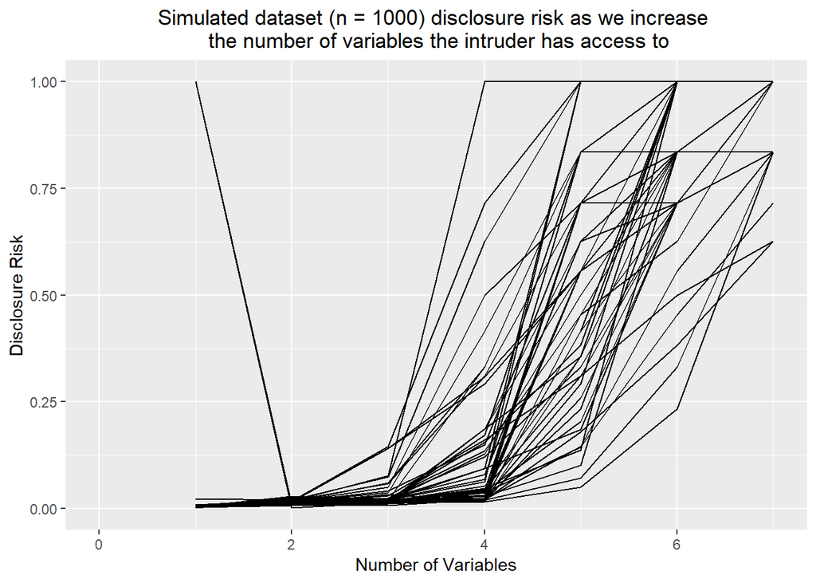

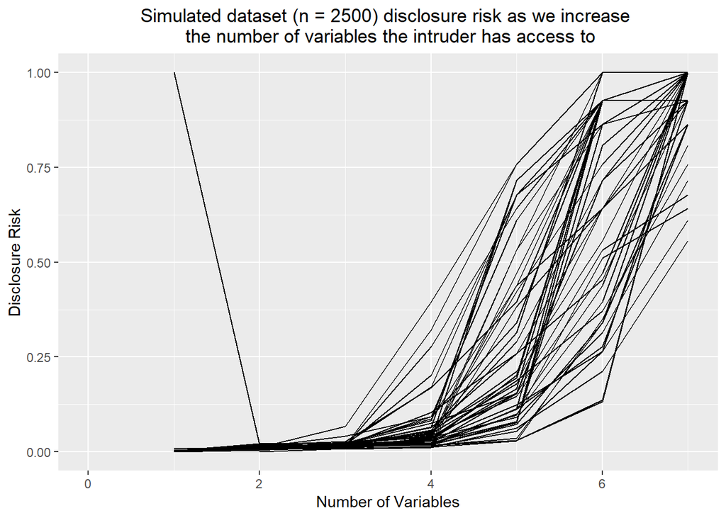

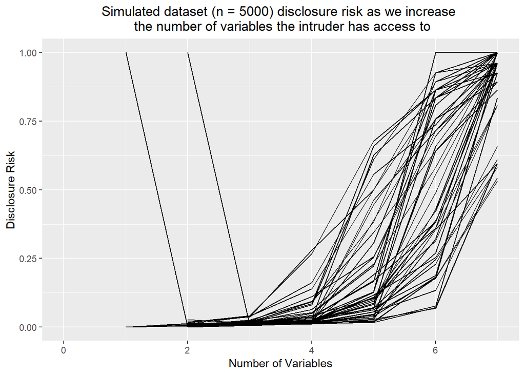

Remember that the DIS method calculates the probability of a correct match given it is a unique match. If there are no unique matches, then the previously mentioned probability is 0. But there might still be a disclosure risk. We can also not that as the sample size increases the number of disclosure risks that can be calculated at 1 variable decreases, this is because for larger data-sets the number of sample uniques and the number of pairs are both 0. Only Gender and age in certain countries can reasonably be assumed to be vaguely uniform. Sometimes the disclosure risk of a data-set is 1 when we have 1 or sometimes 2 variables, this is because there are no pairs however not all observations are sample uniques, they are just in higher equivalence classes.

### Sampling Fractions:

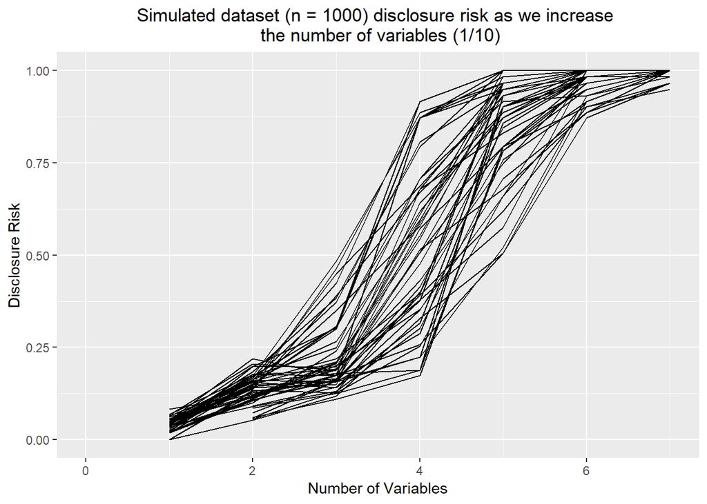

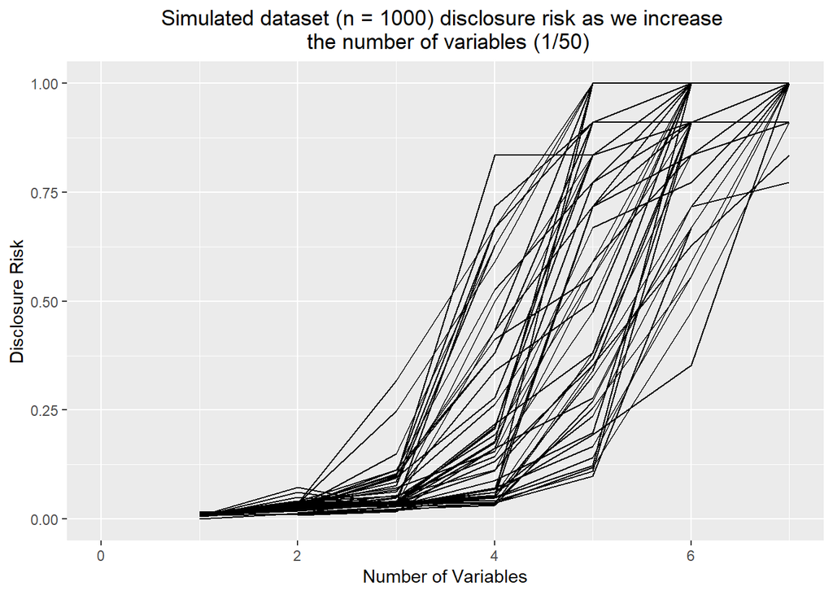

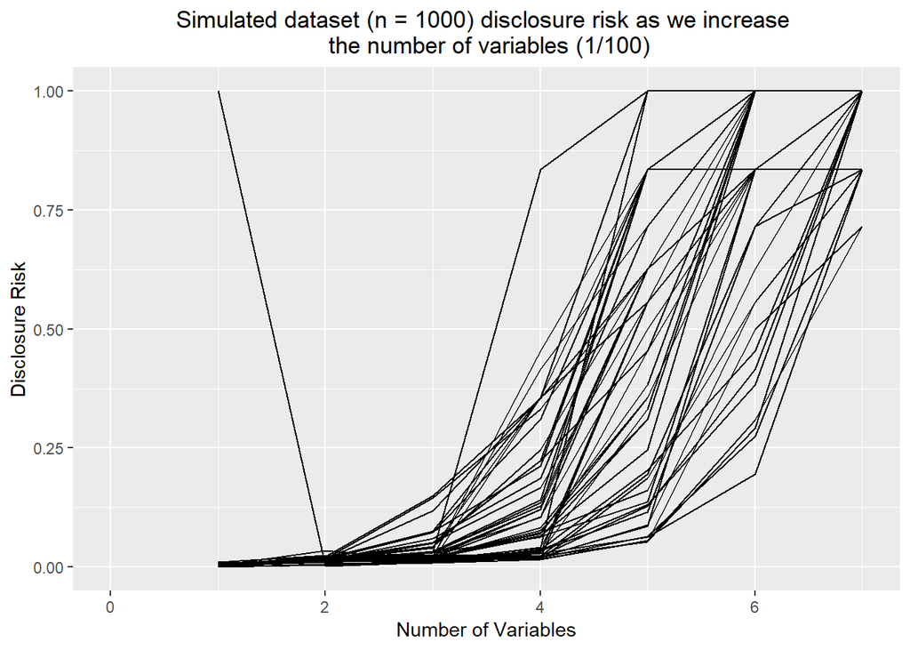

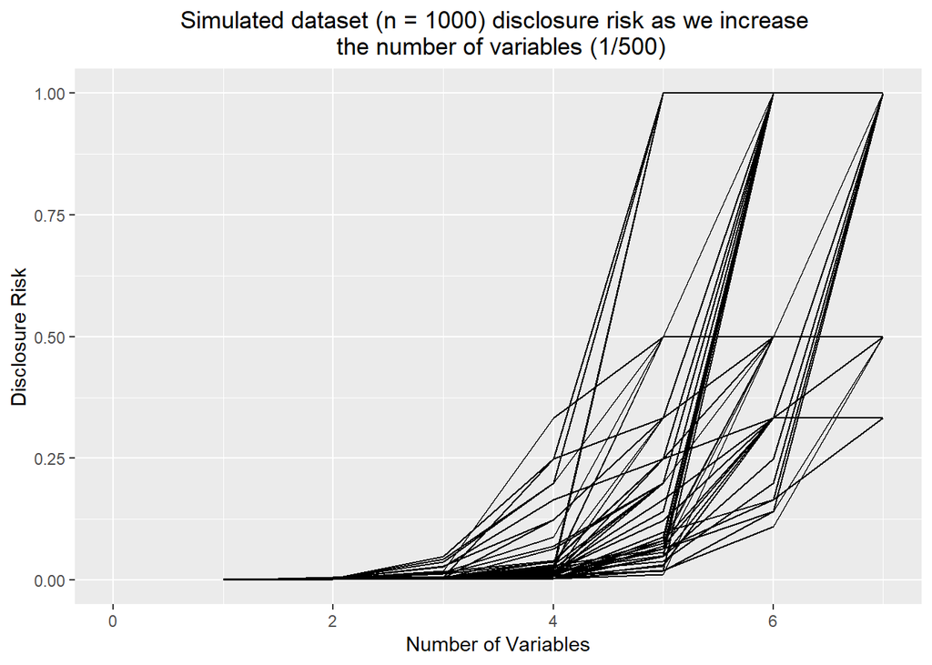

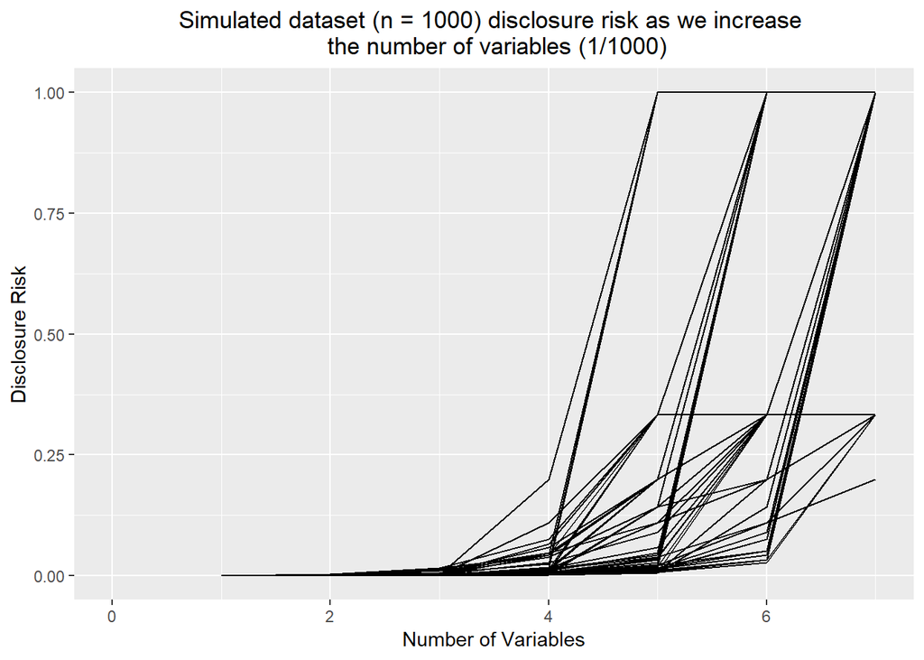

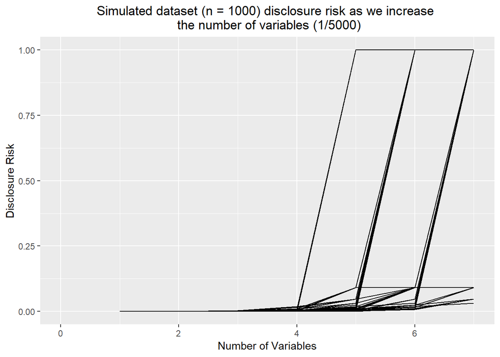